# Modena Time Series Analysis

# Introduction

This R notebook provides code to reproduce results for the paper *Effects of antimicrobial stewardship and infection prevention and control on the incidence of carbapenem resistant gram-negative infections in Modena, Italy: a non-linear time-series analysis*. It requires installing of necessary packages

Data and code are available at the Github repository [via this link](https://github.com/TimLawes/modena_carbapenem_resistance)

# 1. Preliminaries

## 1.1 Install copies of required packages to private library

## 1.2 Load required packages and customised plot theme

## 1.3 Load data and process

## 1.4 Outlier detection and time-series cleaning

```r
# outlier detection and replacement with cleaned values
wide_clean <- tswide %>% as_tibble %>% dplyr::select(date, obd, bedocc,abhr:all_monitored)

newabx.matrix<-rep(0,132)
for(i in 1:length(wide_clean[1,])){
abx<- wide_clean[,i]
newabx<-OutlierTreatment2(abx,freq=12,start.date=c(2008,1), only.clean=TRUE)
newabx.matrix <-cbind(newabx.matrix, newabx)
}

newabx.matrix<-newabx.matrix[,-1]

colnames(newabx.matrix)<-c(paste0(colnames(wide_clean)))
newabx.matrix<- newabx.matrix[,!colnames(newabx.matrix) %in% 'date']

tmp <-tswide %>% dplyr::select(!c(date, obd,bedocc,abhr:all_monitored))

tswide_clean <- cbind(newabx.matrix,tmp) %>% as_tsibble(index=date)
rm(tmp, newab.matrix, date, abx, tswide, wide_clean)
```

## 1.5 Trend decomposition

```r
# create long format data for incidence

tslong <- tswide_clean %>% dplyr::select(!c(hh_adherence:mrsa_all_bsi)) %>%
  pivot_longer(
  cols = csab_all_any:crpa_cohca_swab,
  names_to = c("IR", "org", "pop", "site"),
  names_pattern = "(cr|cs)(ab|kp|pa)_(.*)_(.*)",
  values_to = "incidence") %>% filter(pop!="NA")

tslong<- tslong %>% mutate (bugs = paste(IR,org,pop,site))

tslong <- tslong %>% dplyr::select(-bedocc) %>% group_by(bugs,IR,org,pop,site) %>% nest()

tslongbugs<- tslong %>% filter(pop=="hca" | pop=="conothca")

decompose <- function(data, y, ...){
    y <- enquo(y)
    dvar <- data %>% pull(!!y) %>% as.ts()
    tmpd <- data %>% model(STL(dvar ~ trend(window = 7) +
                                 season(window =13), robust = TRUE)) %>%
      components()
    data <-cbind(data,tmpd[,3:6])
}

ts_decomp <- tslongbugs %>%
    mutate(decs = map(data, decompose, y = incidence)) %>%
    dplyr::select(-data) %>% unnest(decs) %>% ungroup()
ts_decomp <- ts_decomp %>% mutate (trend=if_else(trend <0, 0, trend))
```

# 3. ARIMAs

- Primary outcomes
- Antibiotic time-series - for counterfactuals
- Other infection time-series driving antibiotic use

## 3.1 Primary outcomes

The primary study outcomes of interest are:

- crpa hca clinical,
- crpa conothca clinical,
- crkp hca clinical,
- crkp conothca clinical,
- crab hca clinical,
- crab conothca clinical

### 3.1.1 Redefine timeseries datasets for ARIMAs

### 3.1.2 HCA-CRKp clinical infections (*crkp hca clinical*)

### 3.1.3 HCA-CRAb clinical infections (*crab hca clinical*)

### 3.1.4 HCA-CRPa clinical infections (*crpa hca clinical*)

## 3.2 Antibiotic and IPC time series

```r
# Nb: we use the pre-intervention dataset "ts_p2_pre_icarba" for fitting the baseline ARIMA with exogenous variables (ARIMAX) for carbapenems. For other antibiotics we should use the  "ts_p3_pre_iabs_iunivscr" data
pre_icarba <- ts_p2_pre_icarba %>% as_tsibble(index="date")
pre_iabs <- ts_p3_pre_iabs_iunivscr %>% as_tsibble(index="date")
```

## 3.3 Influential infection time-series

These time-series are expected to be related to antibiotic use in the population. Bidirectional relationships may exist but we hypothesised that hospital-wide use of important antibiotic exposures driving carbapenem resistance may be responsive to the following:

- All gram-negative bloodstream isolates (BSIs) (*gmneg_all_bsi*)
- Carbapenem and cephalosporin sensitive E.coli BSI (*ecoliccs_all_bsi*)
- 3rd generation cephalosporins resistant E.coli BSI (*ecoli3gcr_all_bsi*)

### 3.3.1 Gram-Neg BSIs

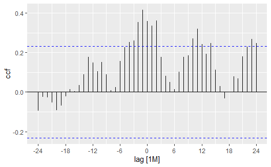

```r
### Carbapenems######################

# Prepare differenced time-series
pre_icarba$gmneg_diff <-  tsibble::difference(pre_icarba$gmneg_all_bsi, lag =1, differences = 1)
pre_icarba$carbapenem_diff <-  tsibble::difference(pre_icarba$carbapenem, lag =1, differences = 1)
pre_icarba_ed2 <- pre_icarba [2:72,] %>% as_tsibble(index="date")
pre_icarba_ed4 <- pre_icarba [4:72,] %>% as_tsibble(index="date")

# Explore cross-correlations with raw data
CCF(pre_icarba, carbapenem, gmneg_all_bsi, lag_max=24) %>% autoplot(level=95)
```

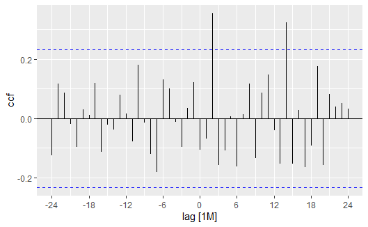

```r
# Explore cross-correlations with differenced data
CCF(pre_icarba_ed2, carbapenem_diff, gmneg_diff, lag_max=24)%>% autoplot(level=95)
```

```r
# Identify an ARIMAX model for carbapenems
carba_pre1 <- pre_icarba %>% model(ARIMA(carbapenem~ -1 + pdq(0,1,1)+PDQ(0,0,0)+lag(gmneg_all_bsi,2)))
report(carba_pre1)
```

```
Series: carbapenem
Model: LM w/ ARIMA(0,1,1) errors

Coefficients:
          ma1  lag(gmneg_all_bsi, 2)
      -0.4281                 0.5031
s.e.   0.1147                 0.1689

sigma^2 estimated as 44.57:  log likelihood=-229
AIC=464.01   AICc=464.37   BIC=470.8
```

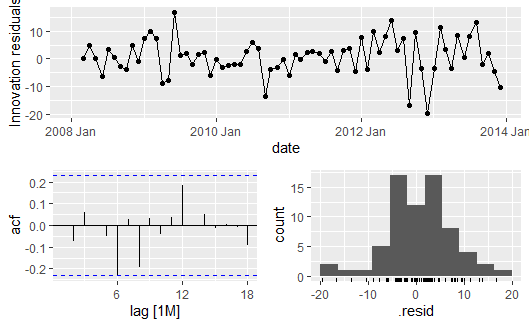

```r
carba_pre1 %>%  gg_tsresiduals()
```

```r
carba_pre2 <- pre_icarba_ed2 %>% model(ARIMA(carbapenem  ~ -1 + pdq(0,1,1)+PDQ(0,0,0)+lag(gmneg_diff,2)))
report(carba_pre2)
```

```
Series: carbapenem
Model: LM w/ ARIMA(0,1,1) errors

Coefficients:
          ma1  lag(gmneg_diff, 2)
      -0.4723              0.3559
s.e.   0.1144              0.1251

sigma^2 estimated as 45.42:  log likelihood=-226.35
AIC=458.71   AICc=459.07   BIC=465.45
```

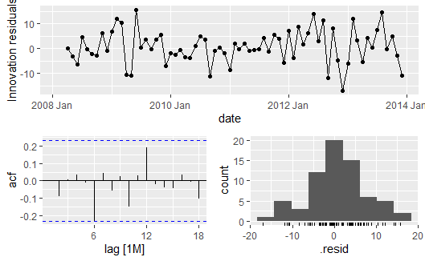

```r
carba_pre2 %>%  gg_tsresiduals()
```

```r
# Looking at the correlation between gm neg BSI and differenced gm neg BSI (y-axis)
gmneg_bsi<- pre_icarba$gmneg_all_bsi[1:71]
differenced_gm_negbsi <- pre_icarba$gmneg_diff [2:72]
gmneg <- cbind(gmneg_bsi,differenced_gm_negbsi )
gmneg <-gmneg %>% as_tibble()
cor(gmneg$gmneg_bsi, gmneg$differenced_gm_negbsi)
```

```
[1] -0.5079191
```

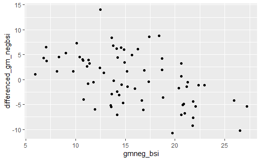

```r
ggplot(gmneg, aes(gmneg_bsi,differenced_gm_negbsi))+geom_point()
```

# 4. Interactions and VARs

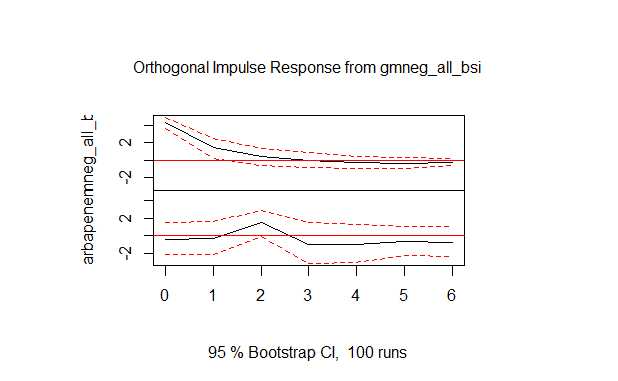

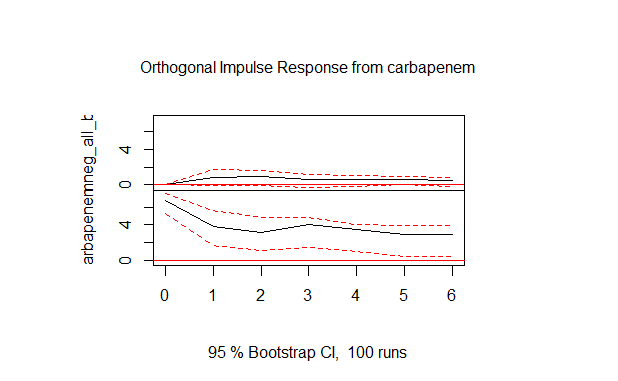

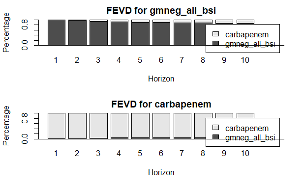

```r
### VAR evaluation function
library(lmtest)  # install.packages("lmtest")
library(vars)    # install.packages("vars")


# Defining function for VAR evaluation 2 variables y and series
eval_var<-function(y, series, names){

  # Make series to be stationary

dy=0; dseries=0

if(unitroot_ndiffs(y)!=0){dy<-unitroot_ndiffs(y);y<-diff(y, differences=dy)}
if(unitroot_ndiffs(series)!=0){dseries<-unitroot_ndiffs(series); series<-diff(series, differences=dseries)}

if(dy>dseries){series<-head(series,-I(dy-dseries))}
if(dy<dseries){y<-head(y,-I(dseries-dy))}

assign(names[1],y)
assign(names[2],series)

  # Select order and estimate VAR
matrix<-cbind(y,series)
colnames(matrix)<-names

var.fit <- vars::VAR(matrix,lag.max = 4, ic="AIC")

  # Some test form var estimation
serial.test<-serial.test(var.fit, lags.pt=10, type="PT.asymptotic")

normality.test <- normality.test(var.fit)

var.stability <- stability(var.fit, type = "Rec-CUSUM")

   # Impulse response function

impulse.response <- vars::irf(var.fit , n.ahead = 6, ortho = TRUE,
               cumulative = F, boot = TRUE, ci = 0.95, runs = 100)

  # Variance decomposition of the forecasts

var.decomp<-fevd(var.fit)

  # causality analysis

causality<- list(cause.y=vars::causality(var.fit,  cause=names[1],boot=TRUE, boot.runs=1000)$Granger, cause.series=vars::causality(var.fit, cause=names[2], boot=TRUE, boot.runs=1000)$Granger)


return(
  list(
    var.fit=var.fit,
    causality=causality,
    impulse.response=impulse.response,
    serial.test=serial.test,
    normality.test=normality.test,
    var.stability=var.stability,
    var.decomp=var.decomp
    )
  )
}



### VAR Gram Negative, ecoliccs ecoli3gcr( Pre_icarba[,18:20]) => abx( Pre_icarba[,5:9])


for (n in 18:20){

 for(j in 5:9){
names<-colnames(pre_icarba)[c(n,j)]
var<-eval_var(y=pre_icarba[,n],
              series=pre_icarba[,j],
              names=names)
plot(var$impulse.response)

var$causality$cause.y
var$causality$cause.series

plot(var$var.decomp)

assign(paste0(c("var",colnames(pre_icarba)[n],colnames(pre_icarba)[j]), sep=".", collapse = ""),var)
 }
}
```

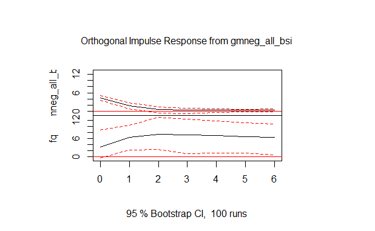

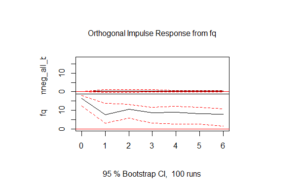

```
Error in vars::causality(var.fit, cause = names[2], boot = TRUE, boot.runs = 1000) :
  Argument cause does not match variables names.
```

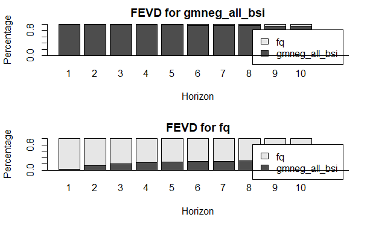

```r
NA
```

Direction of interactions between populations

```
crab_ho_swab<=>crab_ho_clinical
```

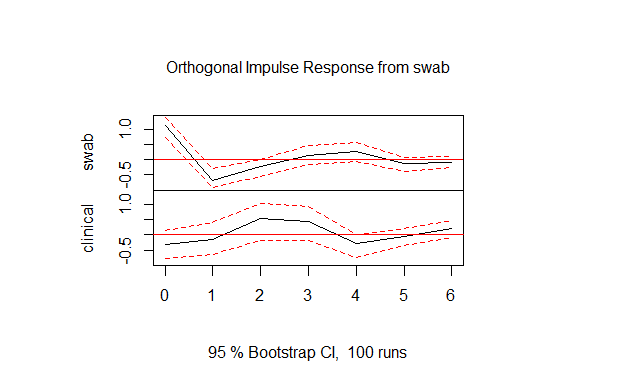

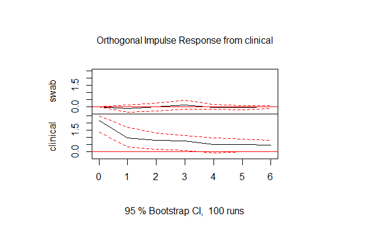

```
crab_cohca_swab<=>crab_cohca_clinical
```

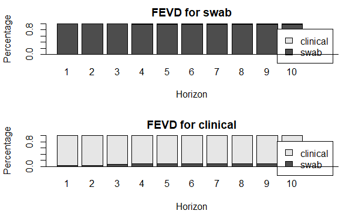

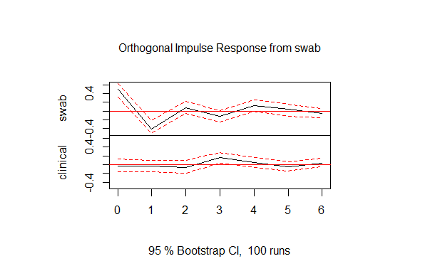

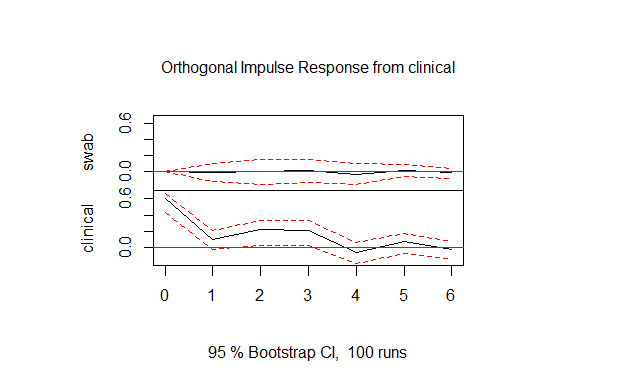

```
crab_conothca_swab<=>crab_conothca_clinical
```

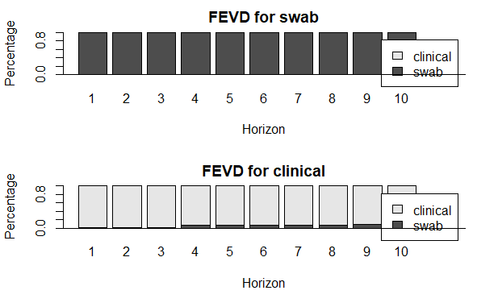

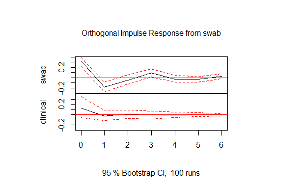

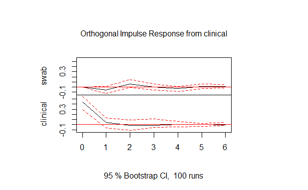

```
crab_hca_swab<=>crab_hca_clinical
```

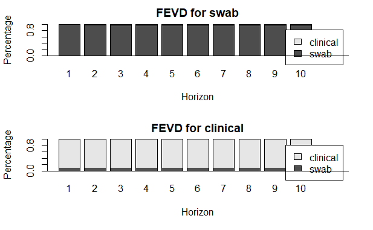

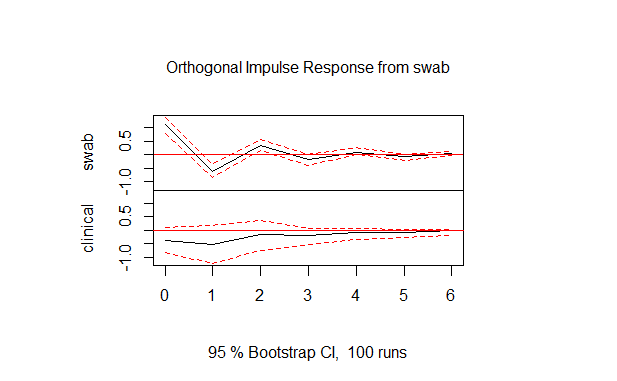

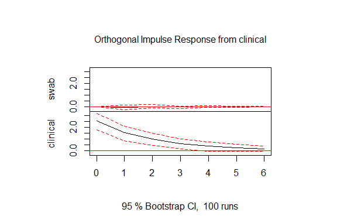

```
crkp_ho_swab<=>crkp_ho_clinical
```

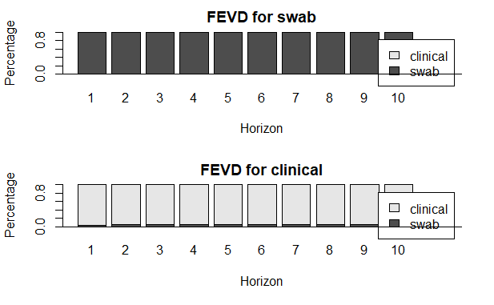

[24 more figures not shown]

```r
pathogen<-c("crab","crkp","crpa")
pop<-c("ho","cohca","conothca", "hca")


for (n in 1:3){

 for(j in 1:4){

names.var<-c(paste("pre_icarba$", paste(pathogen[n],pop[j],"swab",sep="_"), sep=""),paste("pre_icarba$", paste(pathogen[n],pop[j],"clinical",sep="_"), sep=""))

names<-c(paste(pathogen[n],pop[j],"swab",sep="_"),paste(pathogen[n],pop[j],"clinical",sep="_"))
names0<-c("swab","clinical")


var<-eval_var(y=eval( parse(text=names.var[1])),
              series=eval( parse(text=names.var[2])),
              names=names0)
cat(paste(names[1],names[2],sep="<=>"))
plot(var$impulse.response) # It is necessary to put irf in one plot and common title for <org> <pop>

var$causality$cause.y
var$causality$cause.series

plot(var$var.decomp)

assign(paste0(c("var",names[2],names[1]), sep=".", collapse = ""),var)
 }
}
```

Interspecies competition

[figure not shown]

[figure not shown]

Interaction among sensitive and resistant strains

```
crab_ho_clinical<=>csab_ho_clinical
```

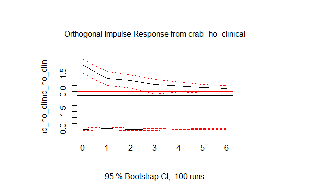

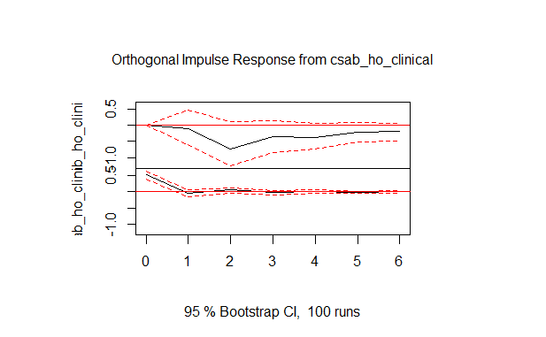

```
crab_cohca_clinical<=>csab_cohca_clinical
```

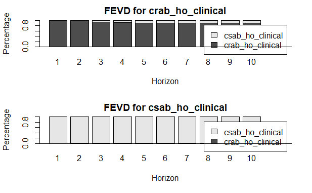

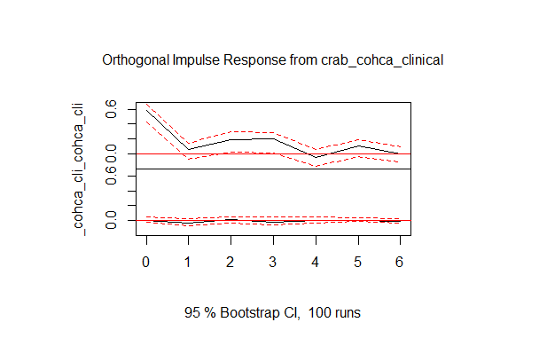

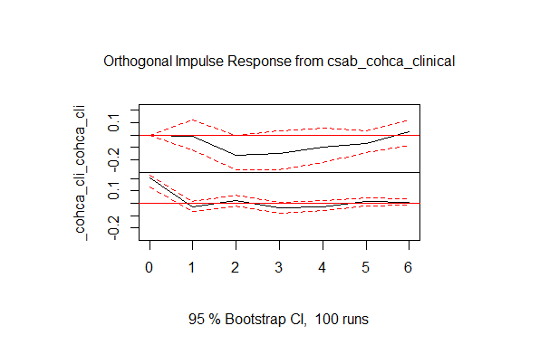

```
crab_conothca_clinical<=>csab_conothca_clinical
```

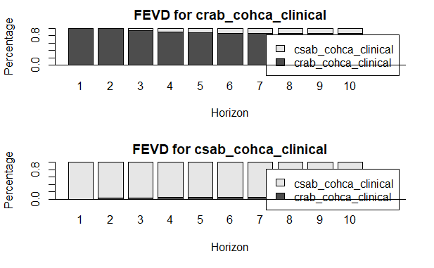

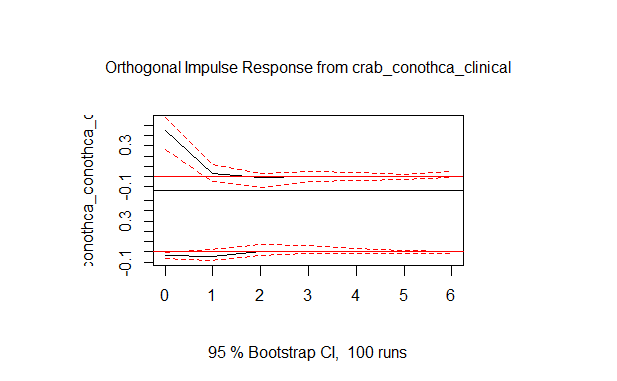

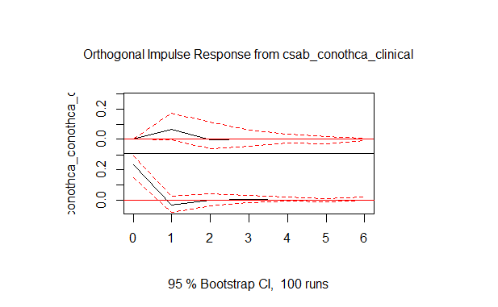

```
crab_hca_clinical<=>csab_hca_clinical
```

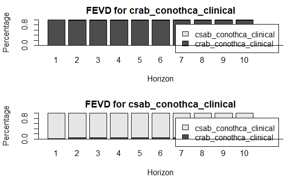

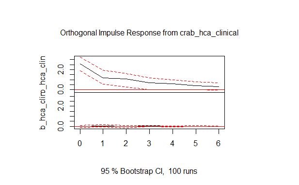

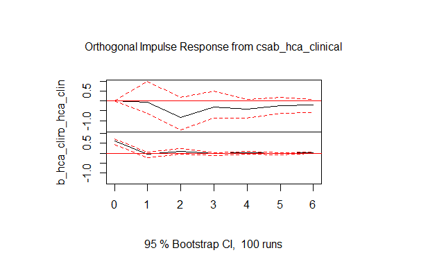

```
crkp_ho_clinical<=>cskp_ho_clinical
```

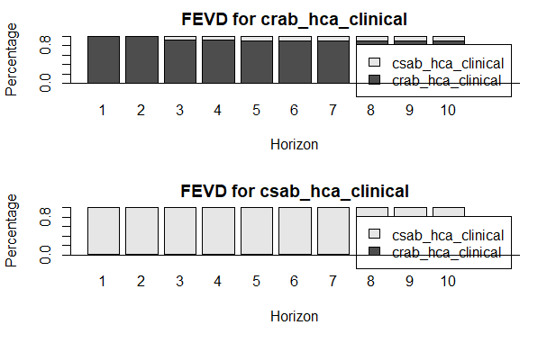

[24 more figures not shown]

```r
pathogen0<-rbind(c("crab","crkp","crpa"),c("csab","cskp","cspa"))

pop<-c("ho","cohca","conothca", "hca")


for (n in 1:3){

 for(j in 1:4){

names.var<-c(paste("pre_icarba$", paste(pathogen0[1,n],pop[j],"clinical",sep="_"), sep=""),paste("pre_icarba$", paste(pathogen0[2,n],pop[j],"clinical",sep="_"), sep=""))

names<-c(paste(pathogen0[1,n],pop[j],"clinical",sep="_"),paste(pathogen0[2,n],pop[j],"clinical",sep="_"))

var<-eval_var(y=eval( parse(text=names.var[1])),
              series=eval( parse(text=names.var[2])),
              names=names)

cat(paste(names[1],names[2],sep="<=>"))
plot(var$impulse.response) # It is necessary to put irf in one plot and common title for <org> <pop>

var$causality$cause.y
var$causality$cause.series

plot(var$var.decomp)

assign(paste0(c("var",names[2],names[1]), sep=".", collapse = ""),var)
 }
}
```

# Attempt to add ggplot function

```r
for (n in 18:20){

 for(j in 5:9) {
names<-colnames(pre_icarba)[c(n,j)]
var<-eval_var(y=pre_icarba[,n],
              series=pre_icarba[,j],
              names=names)

ext<- extract_varirf(var[["impulse.response"]]) %>%
  pivot_longer(!period,
  names_to= c(".value","x","y"),
  names_pattern=c("(.*)[.](.*)[.](.*)"))

var$causality$cause.y
var$causality$cause.series

assign(paste0(c("var",colnames(pre_icarba)[n],colnames(pre_icarba)[j]), sep=".", collapse = ""),var)
assign(paste0(c("ext",colnames(pre_icarba)[n],colnames(pre_icarba)[j]), sep=".", collapse = ""), ext)
 }
}
```

```
Error in vars::causality(var.fit, cause = names[2], boot = TRUE, boot.runs = 1000) :
  Argument cause does not match variables names.
```

# 5. GAMs

# 6. MARS